# JLC 445 Project 3

# Forecast 2: For Forecast 2, my analysis is based on robbery during the evening shift.

Based on this forecast, my prediction for the robberies occurring in the evening shift for the month of December is ranging between 5 and 6 a day. There is about 2 days between every spike of 6 robberies. I expect most of these robberies to take place in the center of the city, near the National Mall, as well as on the Southeast side of D.C., east of the Anacostia river. Robberies during the evening shift are more likely to occur on Wednesday, Thursday, and Saturday, while less likely to occur on Tuesday, Friday, and Sunday.

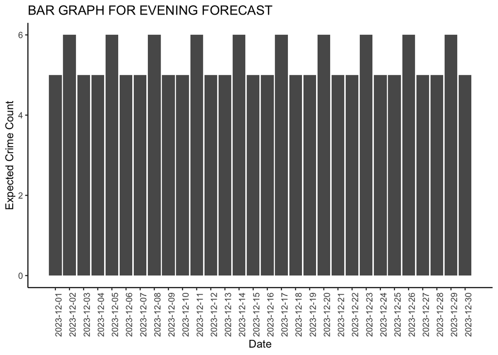

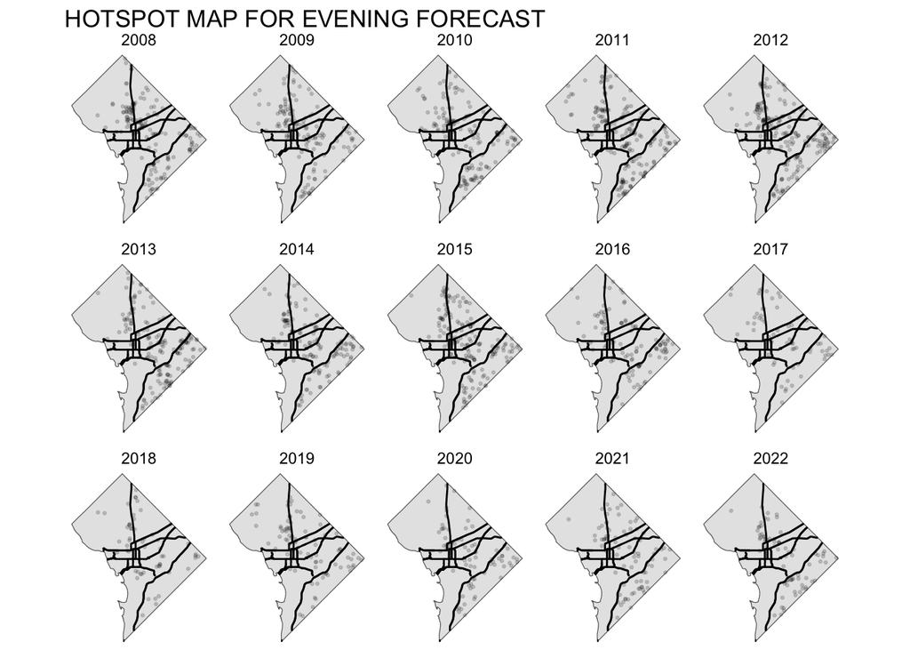

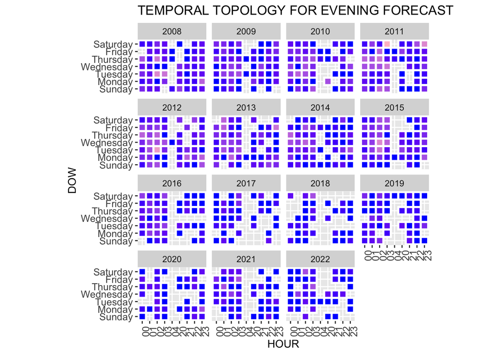